# Reproducible Research Assignment 1

Damian Alcedo

## Introduction

It is now possible to collect a large amount of data about personal movement using activity monitoring devices such as a Fitbit, Nike Fuelband, or Jawbone Up. These type of devices are part of a group of enthusiasts who take measurements about themselves regularly to improve their health, to find patterns in their behavior, or because they are tech geeks.

This study makes use of data from a personal activity monitoring device. This device collects data at 5 minute intervals through out the day. The data consists of two months of data from an anonymous individual collected during the months of October and November, 2012 and include the number of steps taken in 5 minute intervals each day.

## Loading and preprocessing the data

To start the analysis the necesary data is loaded into R and the `date` variable is transfromed in to the date format

```r
data<-read.csv("activity.csv")
data$date<-as.Date(data$date)
```

# What is the mean total number of steps taken per day?

In this part we analyse the mean and the median of the amount of steps taken per day. To do so first we group the data by `date` and summarize by sum `steps`.

```r
by_date <- group_by(data, date)
mean_steps_date<-summarize(by_date, mean(steps))
sum_steps_date<-summarize(by_date, sum(steps))
```

Then we draw a histogram of the total steps taken per day.

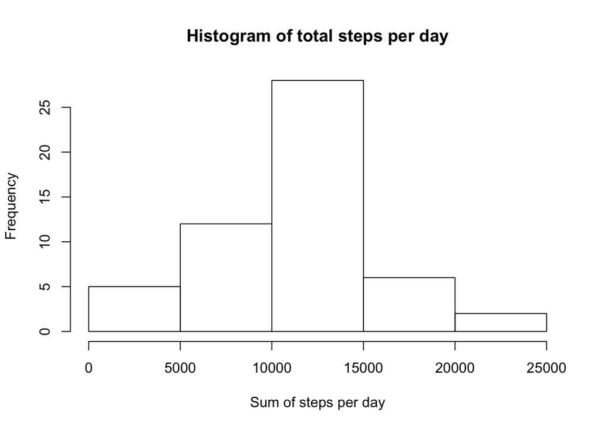

```r
hist(sum_steps_date$sum, xlab = "Sum of steps per day", main = "Histogram of total steps per day")
```

And finaly we calculate the mean and the median of the steps taken per day. As you can see this coincides with the values in the histogram

```r
mean(sum_steps_date$sum, na.rm=TRUE)
```

```
## [1] 10766.19
```

```r
median(sum_steps_date$sum, na.rm=TRUE)
```

```
## [1] 10765
```

## What is the average daily activity pattern?

Now we analyse the average daily activity pattern by drawing a timeseries plot of the average steps taken in each 5 minute interval. To do so we group the data by `interval`, take out the missing values and summarize the data by mean `steps`.

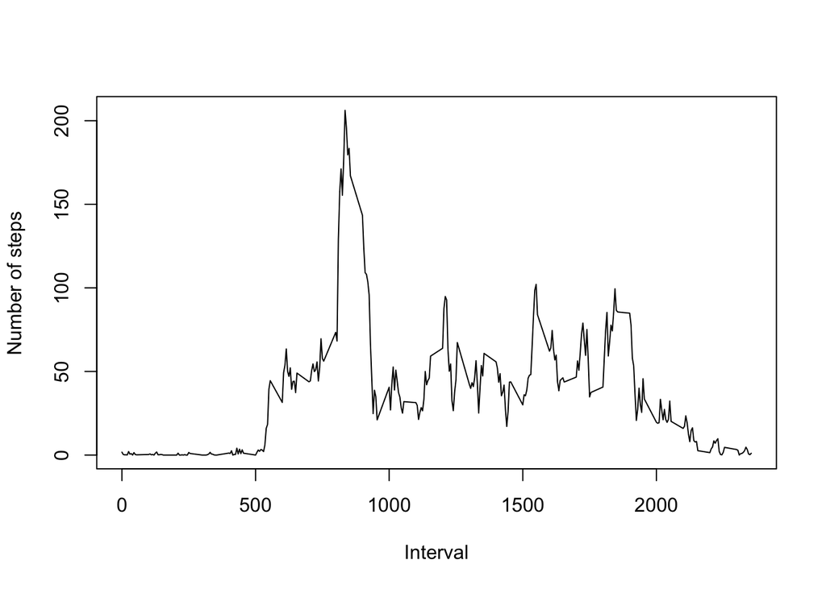

```r
by_interval <- group_by(data, interval)
by_interval<-by_interval[complete.cases(by_interval),]
mean_steps_int<-summarize(by_interval, mean(steps))
plot(mean_steps_int$interval, mean_steps_int$mean, type="l", xlab = "Interval", ylab = "Number of steps")
```

As we can see in the time series plot the highest amount of steps in a 5 minute interval is somewhere between interval 750 and interval 1000. To be exact this is interval 835 with an average of 206.17 steps as we can see in the calculation below.

```r
max(mean_steps_int$mean)
```

```
## [1] 206.1698
```

```r
which.max(mean_steps_int$mean)
```

```
## [1] 104
```

```r
mean_steps_int$interval[104]
```

```
## [1] 835
```

## Imputing missing values

The total number of missing values is:

```r
sum(is.na(data$steps))
```

```
## [1] 2304
```

Before we continue we’re going to replace the missing values with the average of the total steps taken. First we make a new data frame `dat` and then we replace the missing values.

```r
dat<-data
for(i in 1:ncol(dat)){
  dat[is.na(dat[,i]), i] <- mean(dat[,i], na.rm = TRUE)
}
```

Then we analyse the new mean and the median of the amount of steps taken per day. To do so first we group the data by `date` and summarize by sum `steps`.

```r
by_date2 <- group_by(dat, date)
sum_steps_date2<-summarize(by_date, sum(steps))
```

Then we draw a histogram of the total steps taken per day.

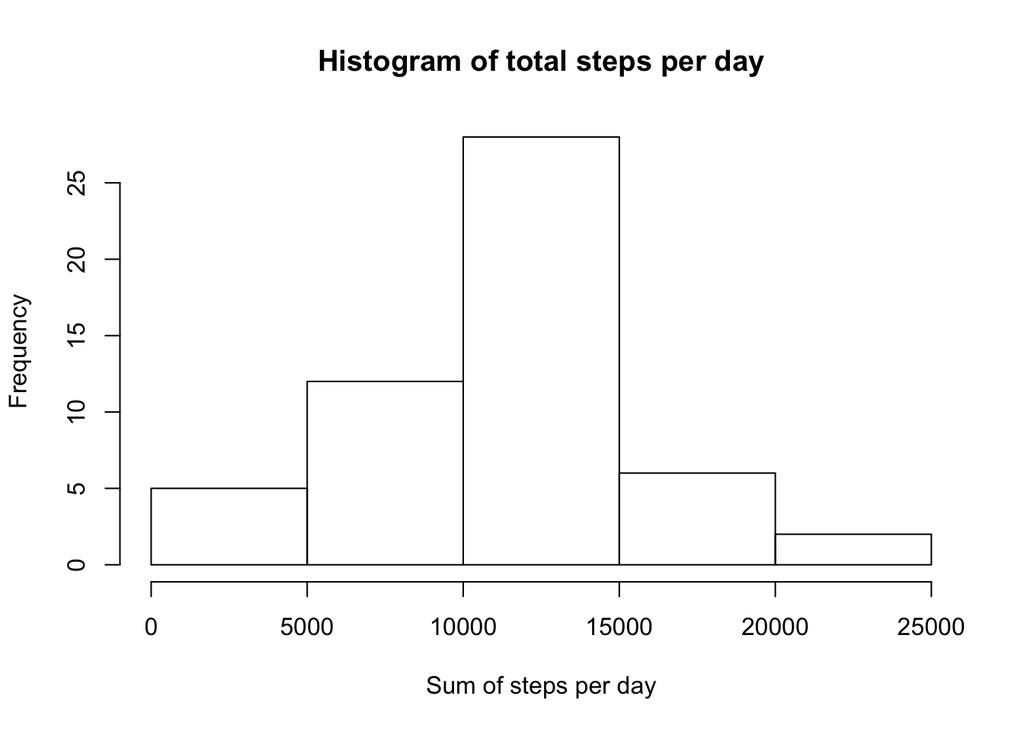

```r
hist(sum_steps_date2$sum, xlab = "Sum of steps per day", main = "Histogram of total steps per day")
```

```r
mean(sum_steps_date2$sum, na.rm=TRUE)
```

```
## [1] 10766.19
```

```r
median(sum_steps_date2$sum, na.rm=TRUE)
```

```
## [1] 10765
```

# Are there differences in activity patterns between weekdays and weekends?

To see if there are differences between weekday and weekend paterns we a new factor variable in the dataset with two levels `weekday` and `weekend` indicating whether a given date is a weekday or weekend day. We do so by creating a new variable with the days of the week. And based on this variable we create a variable with two levels `weekday` and `weekend.

```r
dat<-mutate(dat, weekday=weekdays(date))
dat$weekday<-as.factor(dat$weekday)

dat_we<-filter(dat, weekday=="Saturday" | weekday=="Sunday")
dat_wd<-filter(dat, weekday!="Saturday" & weekday!="Sunday")
dat_we$wd<-"Weekend"
dat_wd$wd<-"Weekday"

dat<-rbind(dat_wd, dat_we)
dat$wd<-as.factor(dat$wd)
dat<-arrange(dat, date)
```

And to answer the question if there are differences between weekday and weekend paterns we draw two timeseries plots aboce eachother, one with the weekday pattern and ne with the weekend pattern. As you can seen there are more steps being taken on weekend days than on weekdays.

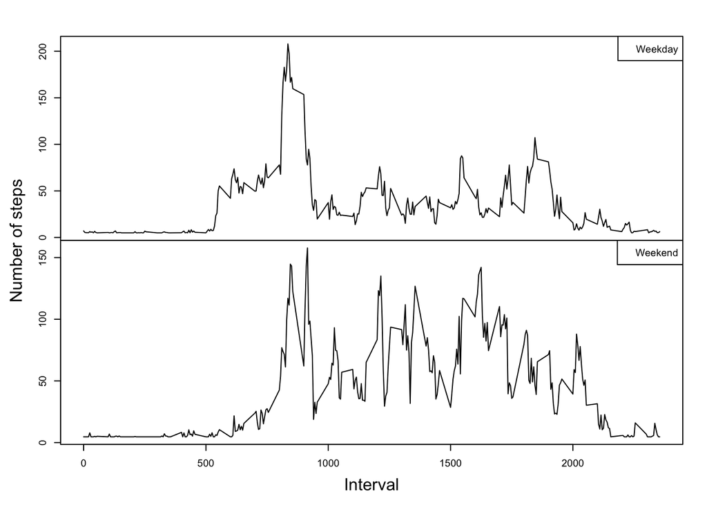

```r
by_weekday <- group_by(dat_wd, interval)
by_weekend <- group_by(dat_we, interval)
mean_weekday<-summarize(by_weekday, mean(steps))
mean_weekend<-summarize(by_weekend, mean(steps))

par(mfrow=c(2,1), cex=0.6, mar = c(0, 0, 0, 0), oma = c(5, 5, 3, 2))
    plot(mean_weekday$interval, mean_weekday$mean, type="l", xaxt='n')
    legend("topright", bty="o",legend="Weekday")
    plot(mean_weekend$interval, mean_weekend$mean, type="l")
    legend("topright", bty="o",legend="Weekend")
    mtext("Interval", side=1, padj=3, outer=TRUE)
    mtext("Number of steps", side=2, padj=-3, outer=TRUE)
```